# Woods_Modeling_3

## Model Equation

```r
cc <- logmodel1$coefficients
(eqn <- paste("P_TARGET = 1 - 1/(1 + exp(", paste(round(cc[1],5), paste(round(cc[-1],5), names(cc[-1]), sep=" * ", collapse=" + "), sep=" + "), "+ e))"))
```

```
[1] "P_TARGET = 1 - 1/(1 + exp( 1.86971 + -0.46365 * LabelAppeal + -0.39331 * AcidIndex + 2.55411 * STARS + -4.46935 * STARSFLAG + e))"
```

## Assignment 4 - Hurdle Modeling - Starts Here

```r
library(pscl)
```

```r
mydata2 <- subset(mydata, select = c('TARGET_BIN', 'LabelAppeal' , 'AcidIndex' , 'STARS', 'STARSFLAG'))

SummaryStats(mydata2)
```

[output not shown]

[output not shown]

[output cut: 59 more lines]

```
 1.0      4.0
 1.0      4.0
 1.0      4.0
 1.0      4.0

+ 5848 more outliers



--- STARSFLAG ---

        n   miss     mean       sd     skew     krts      min     qrt1      mdn     qrt3      max      IQR
     12795      0     0.26     0.44     1.08    -0.83     0.00     0.00     0.00     1.00     1.00     1.00

No (Box plot) outliers
```

The sd (not even sd**2) is great than the mean for multiple columns, so the negative binomial distirbution may produce the best results for the hurdle model.

```
>>> Suggestions
bin_width: set the width of each bin
bin_start: set the start of the first bin
bin_end: set the end of the last bin
Histogram(TARGET, density=TRUE)  # smoothed curve + histogram
Plot(TARGET)  # Violin/Box/Scatterplot (VBS) plot

--- TARGET ---

        n   miss     mean       sd      min      mdn      max
     12795      0     3.03     1.93     0.00     3.00     8.00


(Box plot) Outliers: 17

Small      Large
-----      -----
            8.0
            8.0
            8.0
            8.0
            8.0
            8.0
            8.0
            8.0
            8.0
            8.0
            8.0
            8.0
            8.0
            8.0
            8.0
            8.0
            8.0


Bin Width: 0.5
Number of Bins: 16

       Bin  Midpnt  Count    Prop  Cumul.c  Cumul.p
---------------------------------------------------
 0.0 > 0.5    0.25   2734    0.21     2734     0.21
 0.5 > 1.0    0.75    244    0.02     2978     0.23
 1.0 > 1.5    1.25      0    0.00     2978     0.23
 1.5 > 2.0    1.75   1091    0.09     4069     0.32
 2.0 > 2.5    2.25      0    0.00     4069     0.32
 2.5 > 3.0    2.75   2611    0.20     6680     0.52
 3.0 > 3.5    3.25      0    0.00     6680     0.52
 3.5 > 4.0    3.75   3177    0.25     9857     0.77
 4.0 > 4.5    4.25      0    0.00     9857     0.77
 4.5 > 5.0    4.75   2014    0.16    11871     0.93
 5.0 > 5.5    5.25      0    0.00    11871     0.93
 5.5 > 6.0    5.75    765    0.06    12636     0.99
 6.0 > 6.5    6.25      0    0.00    12636     0.99
 6.5 > 7.0    6.75    142    0.01    12778     1.00
 7.0 > 7.5    7.25      0    0.00    12778     1.00
 7.5 > 8.0    7.75     17    0.00    12795     1.00
```

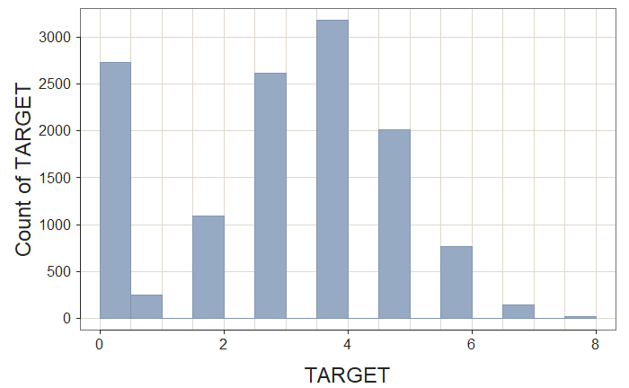

```r
#histogram

Histogram(TARGET, data = mydata)
```

```r
summary(hurdle1 <- hurdle(TARGET ~ LabelAppeal + AcidIndex + STARS + STARSFLAG, data = mydata))
```

```
Call:
hurdle(formula = TARGET ~ LabelAppeal + AcidIndex + STARS + STARSFLAG, data = mydata)

Pearson residuals:
     Min       1Q   Median       3Q      Max
-2.19815 -0.44673 -0.02586  0.41557  5.19474

Count model coefficients (truncated poisson with log link):
             Estimate Std. Error z value             Pr(>|z|)
(Intercept)  1.234328   0.040841  30.223 < 0.0000000000000002 ***
LabelAppeal  0.241899   0.006552  36.919 < 0.0000000000000002 ***
AcidIndex   -0.018753   0.004921  -3.811             0.000138 ***
STARS        0.101959   0.006515  15.650 < 0.0000000000000002 ***
STARSFLAG   -0.176918   0.018687  -9.468 < 0.0000000000000002 ***
Zero hurdle model coefficients (binomial with logit link):
            Estimate Std. Error z value            Pr(>|z|)
(Intercept)  1.86971    0.21564    8.67 <0.0000000000000002 ***
LabelAppeal -0.46365    0.03297  -14.06 <0.0000000000000002 ***
AcidIndex   -0.39331    0.02114  -18.60 <0.0000000000000002 ***
STARS        2.55411    0.11163   22.88 <0.0000000000000002 ***
STARSFLAG   -4.46935    0.11497  -38.88 <0.0000000000000002 ***
---
Signif. codes:  0 '***' 0.001 '**' 0.01 '*' 0.05 '.' 0.1 ' ' 1

Number of iterations in BFGS optimization: 12
Log-likelihood: -2.042e+04 on 10 Df
```

```r
#count of predicted zero values

sum(predict(hurdle1, type = "prob")[,1])
```

```
[1] 2734
```

```r
sum(mydata$TARGET < 1)
```

```
[1] 2734
```

```r
max(mydata$TARGET)
```

```
[1] 8
```

```r
sum(hurdle1$fitted.values < .1)
```

```
[1] 9
```

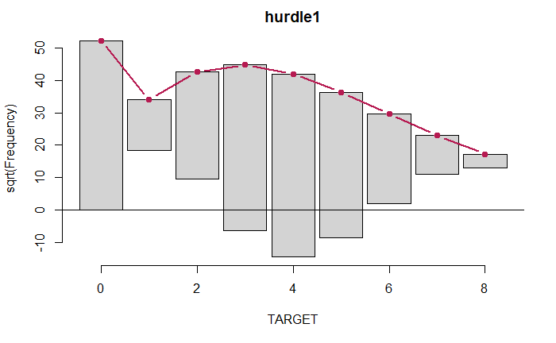

```r
#install.packages("countreg", repos="http://R-Forge.R-project.org")
library(countreg)
rootogram(hurdle1, max = 8) # fit up to count 8
```

We see columns dipping below the zero mark between 3 and 5 wine sales, indicating the poisson model is underfitting these values. This can be improved with a negative binomial distribution?

```r
#hurdle model with negative binomial distribution

summary(hurdle2 <- hurdle(TARGET ~ LabelAppeal + AcidIndex + STARS + STARSFLAG, data = mydata, dist = "negbin"))
```

```
NaNs produced
```

```
Call:
hurdle(formula = TARGET ~ LabelAppeal + AcidIndex + STARS + STARSFLAG, data = mydata, dist = "negbin")

Pearson residuals:
     Min       1Q   Median       3Q      Max
-2.19815 -0.44673 -0.02581  0.41561  5.19432

Count model coefficients (truncated negbin with log link):
             Estimate Std. Error z value             Pr(>|z|)
(Intercept)  1.234166   0.040840  30.219 < 0.0000000000000002 ***
LabelAppeal  0.241910   0.006552  36.921 < 0.0000000000000002 ***
AcidIndex   -0.018740   0.004921  -3.809              0.00014 ***
STARS        0.101986   0.006515  15.654 < 0.0000000000000002 ***
STARSFLAG   -0.176884   0.018687  -9.466 < 0.0000000000000002 ***
Log(theta)  17.429836        NaN     NaN                  NaN
Zero hurdle model coefficients (binomial with logit link):
            Estimate Std. Error z value            Pr(>|z|)
(Intercept)  1.86971    0.21564    8.67 <0.0000000000000002 ***
LabelAppeal -0.46365    0.03297  -14.06 <0.0000000000000002 ***
AcidIndex   -0.39331    0.02114  -18.60 <0.0000000000000002 ***
STARS        2.55411    0.11163   22.88 <0.0000000000000002 ***
STARSFLAG   -4.46935    0.11497  -38.88 <0.0000000000000002 ***
---
Signif. codes:  0 '***' 0.001 '**' 0.01 '*' 0.05 '.' 0.1 ' ' 1

Theta: count = 37126287.5905
Number of iterations in BFGS optimization: 41
Log-likelihood: -2.042e+04 on 11 Df
```

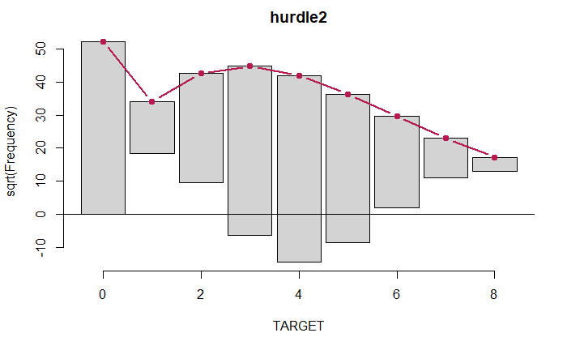

```r
rootogram(hurdle2, max = 8)
```

This looks identical to the prior model.

```r
AIC(hurdle1)
```

```
[1] 40869.04
```

```r
AIC(hurdle2)
```

```
[1] 40871.04
```

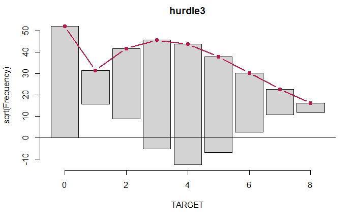

```r
hurdle3 <- hurdle(TARGET ~ STARS, data = mydata, dist = "negbin")

rootogram(hurdle3, max = 8)
```

```r
AIC(hurdle3)
```

```
[1] 47702.7
```